# Community Dynamics

Nick Chang

2025-03-21

Reading in data

```r
#pointsPlots = read.csv('../data/pointsPlots.csv')

points = read.csv("../data/points_2025-01-29.csv")

plots = read.csv("../data/plots_2025-01-29.csv")

pointsWide = read.csv("../data/pointsWide_2024-12-22.csv")

bands = read.csv("../data/bands_2025-01-29.csv")

bandRocks = read.csv("../data/MicrohabAvail_2025-02-20.csv")


cols = c('CHOW' = '#0c9896',
        'PSRUB' = "#C95945",
         "ECIR" = "#E6BC52",
         'EGUT' = '#E68E1C',
         "DCHE" = "#5D695C",
          #"DCHE" = "#70665e",
          "DPER" = "#81705c",
          #'DPER' = '#AFA060',
         'CAM' = "#c7a891"
         )

habCols = c("stream" = "#9BC4BC", "margin" = "#4B5043", "terrestrial" = "#598218")
```

Reading out a breakdown of how many escaped, NOID desmognathus there were:

```r
points %>% group_by(Species, Escaped) %>% summarize(n())
```

```
## # A tibble: 16 × 3
## # Groups:   Species [10]
##    Species Escaped `n()`
##    <chr>   <chr>   <int>
##  1 CAM     NO         52
##  2 CAM     YES         4
##  3 CHOW    NO          8
##  4 D       NO          1
##  5 D       YES         3
##  6 DCHE    NO         24
##  7 DCHE    YES        10
##  8 DPER    NO         56
##  9 DPER    YES        22
## 10 ECIR    NO         23
## 11 ECIR    YES        11
## 12 EGUT    NO          1
## 13 PSRUB   NO          4
## 14 PSRUB   YES         2
## 15 SAL     YES         1
## 16 <NA>    <NA>      186
```

```r
points %>% filter(Species %in% c("D", "SAL")) %>% select(Escaped, Species)
```

```
##   Escaped Species
## 1     YES       D
## 2     YES       D
## 3     YES     SAL
## 4     YES       D
## 5      NO       D
```

```r
pointsWide %>% filter(DCHE > 1) %>% select(CoverType, DCHE)
```

```
##   CoverType DCHE
## 1         R    2
## 2         R    2
```

```r
#creating the cover item position variable (stream/margin/terr)
points = points  %>%
  mutate(hab = ifelse(distWater > 50, "terrestrial", NA)) %>%
  mutate(hab = ifelse(cmDepth > 1, "stream", hab)) %>%
  mutate(hab = ifelse(is.na(hab) == T, "margin", hab)) %>%
  mutate(hab = as.factor(hab)) %>%
  mutate(distDepth = distWater - cmDepth)
# I am going to create a color palette to make this easier to interpret
```

# Morphometrics

Here, we are mostly looking at intraspecific habitat partitiioning within D cheaha

## Sample Size Overview

```r
points %>% filter(Occupied == 1) %>%
  group_by(Species, Escaped) %>%
  summarize(n())
```

```
## # A tibble: 15 × 3
## # Groups:   Species [9]
##    Species Escaped `n()`
##    <chr>   <chr>   <int>
##  1 CAM     NO         52
##  2 CAM     YES         4
##  3 CHOW    NO          8
##  4 D       NO          1
##  5 D       YES         3
##  6 DCHE    NO         24
##  7 DCHE    YES        10
##  8 DPER    NO         56
##  9 DPER    YES        22
## 10 ECIR    NO         21
## 11 ECIR    YES        11
## 12 PSRUB   NO          4
## 13 PSRUB   YES         2
## 14 SAL     YES         1
## 15 <NA>    <NA>        2
```

Across all of our study sites, we had 24 captures of D. cheaha and 10 escapes.

```r
points %>% filter(Occupied == 1 & Species == "DCHE") %>%
  group_by(StrmID, Escaped) %>%
  summarize(n())
```

```
## # A tibble: 11 × 3
## # Groups:   StrmID [7]
##    StrmID Escaped `n()`
##    <chr>  <chr>   <int>
##  1 STRM01 NO          5
##  2 STRM01 YES         2
##  3 STRM02 NO          5
##  4 STRM02 YES         1
##  5 STRM04 NO          2
##  6 STRM04 YES         1
##  7 STRM06 NO          1
##  8 STRM07 NO         11
##  9 STRM07 YES         2
## 10 STRM08 YES         3
## 11 STRM10 YES         1
```

When we look at a breakdown of escapes at each site, we find that we did not have any successful captures of D cheaha, at two of our sites which leaves our count of streams with successful captures at n = 5.

```r
points %>% filter(Occupied ==1 & Species == "DCHE" & Escaped == "NO") %>%
  group_by(StrmID)%>%
  summarize(n())
```

```
## # A tibble: 5 × 2
##   StrmID `n()`
##   <chr>  <int>
## 1 STRM01     5
## 2 STRM02     5
## 3 STRM04     2
## 4 STRM06     1
## 5 STRM07    11
```

```r
pointsDCHE = points %>% filter(Species == "DCHE")

pointsDCHE2 = pointsDCHE %>% filter(Escaped =="NO" & CoverType %in% c("R", "W")) %>%
  mutate(rocky = per_grav + per_rock)
```

## linear regression of DCHE body size as a function of cover object area and location

```r
habUseDCHE_null = glmmTMB(mmSVL ~ (1|StrmID), data = pointsDCHE2)



habUseDCHE = glmmTMB(mmSVL ~ hab + covArea + (1|StrmID), data = pointsDCHE2)

summary(habUseDCHE)
```

```
##  Family: gaussian  ( identity )
## Formula:          mmSVL ~ hab + covArea + (1 | StrmID)
## Data: pointsDCHE2
##
##      AIC      BIC   logLik deviance df.resid
##    175.7    181.2    -82.9    165.7       17
##
## Random effects:
##
## Conditional model:
##  Groups   Name        Variance Std.Dev.
##  StrmID   (Intercept) 16.81    4.100
##  Residual             97.40    9.869
## Number of obs: 22, groups:  StrmID, 5
##
## Dispersion estimate for gaussian family (sigma^2): 97.4
##
## Conditional model:
##              Estimate Std. Error z value Pr(>|z|)
## (Intercept) 44.952173   4.330828  10.380   <2e-16 ***
## habstream    7.578193   4.913133   1.542   0.1230
## covArea      0.010513   0.004607   2.282   0.0225 *
## ---
## Signif. codes:  0 '***' 0.001 '**' 0.01 '*' 0.05 '.' 0.1 ' ' 1
```

```r
tab_model(habUseDCHE)
```

|  | mmSVL |  |  |
| --- | --- | --- | --- |
| Predictors | Estimates | CI | p |
| (Intercept) | 44.95 | 36.46 – 53.44 | **<0.001** |
| hab [stream] | 7.58 | -2.05 – 17.21 | 0.123 |
| covArea | 0.01 | 0.00 – 0.02 | **0.022** |
| Random Effects |  |  |  |
| σ<sup>2</sup> | 97.40 |  |  |
| τ<sub>00</sub> <sub>StrmID</sub> | 16.81 |  |  |
| ICC | 0.15 |  |  |
| N <sub>StrmID</sub> | 5 |  |  |
| Observations | 22 |  |  |
| Marginal R<sup>2</sup> / Conditional R<sup>2</sup> | 0.413 / 0.499 |  |  |

```r
habUseDCHE
```

```
## Formula:          mmSVL ~ hab + covArea + (1 | StrmID)
## Data: pointsDCHE2
##      AIC      BIC   logLik df.resid
## 175.7322 181.1874 -82.8661       17
## Random-effects (co)variances:
##
## Conditional model:
##  Groups   Name        Std.Dev.
##  StrmID   (Intercept) 4.100
##  Residual             9.869
##
## Number of obs: 22 / Conditional model: StrmID, 5
##
## Dispersion estimate for gaussian family (sigma^2): 97.4
##
## Fixed Effects:
##
## Conditional model:
## (Intercept)    habstream      covArea
##    44.95217      7.57819      0.01051
```

```r
anova(habUseDCHE_null, habUseDCHE, test = "Chisq")
```

```
## Data: pointsDCHE2
## Models:
## habUseDCHE_null: mmSVL ~ (1 | StrmID), zi=~0, disp=~1
## habUseDCHE: mmSVL ~ hab + covArea + (1 | StrmID), zi=~0, disp=~1
##                 Df    AIC    BIC  logLik deviance  Chisq Chi Df Pr(>Chisq)
## habUseDCHE_null  3 183.25 186.52 -88.623   177.25
## habUseDCHE       5 175.73 181.19 -82.866   165.73 11.514      2    0.00316 **
## ---
## Signif. codes:  0 '***' 0.001 '**' 0.01 '*' 0.05 '.' 0.1 ' ' 1
```

## Are cover area and position correlated?

```r
sealStreams = c("STRM01", "STRM02", "STRM04", "STRM06", "STRM07", "STRM08", "STRM10")

pWS = pointsWide %>% filter(StrmID %in% sealStreams & CoverType %in% c("R", "W")) %>%
  mutate(hab = ifelse(distWater > 50, "terrestrial", NA)) %>%
  mutate(hab = ifelse(cmDepth > 1, "stream", hab)) %>%
  mutate(hab = ifelse(is.na(hab) == T, "margin", hab)) %>%
  mutate(hab = as.factor(hab)) %>% filter(hab %in% c("stream", "margin"))
```

This is available in the text as *Supplemental Table 4*

```r
habType = glmmTMB(covArea ~ hab + (1|StrmID), data = pWS)
confint(habType)
```

```
##                                2.5 %   97.5 %    Estimate
## (Intercept)                232.49540 410.5622 321.5288091
## habstream                  -21.19014 209.1816  93.9957492
## Std.Dev.(Intercept)|StrmID       NaN      NaN   0.1401734
```

```r
summary(habType)
```

```
##  Family: gaussian  ( identity )
## Formula:          covArea ~ hab + (1 | StrmID)
## Data: pWS
##
##      AIC      BIC   logLik deviance df.resid
##       NA       NA       NA       NA      232
##
## Random effects:
##
## Conditional model:
##  Groups   Name        Variance  Std.Dev.
##  StrmID   (Intercept) 1.965e-02   0.1402
##  Residual             1.960e+05 442.7580
## Number of obs: 236, groups:  StrmID, 7
##
## Dispersion estimate for gaussian family (sigma^2): 1.96e+05
##
## Conditional model:
##             Estimate Std. Error z value Pr(>|z|)
## (Intercept)   321.53      45.43   7.078 1.46e-12 ***
## habstream      94.00      58.77   1.599     0.11
## ---
## Signif. codes:  0 '***' 0.001 '**' 0.01 '*' 0.05 '.' 0.1 ' ' 1
```

```r
tab_model(habType)
```

|  | covArea |  |  |
| --- | --- | --- | --- |
| Predictors | Estimates | CI | p |
| (Intercept) | 321.53 | 232.50 – 410.56 | **<0.001** |
| hab [stream] | 94.00 | -21.19 – 209.18 | 0.110 |
| Random Effects |  |  |  |
| σ<sup>2</sup> | 196034.64 |  |  |
| τ<sub>00</sub> <sub>StrmID</sub> | 0.02 |  |  |
| ICC | 0.00 |  |  |
| N <sub>StrmID</sub> | 7 |  |  |
| Observations | 236 |  |  |
| Marginal R<sup>2</sup> / Conditional R<sup>2</sup> | 0.011 / 0.011 |  |  |

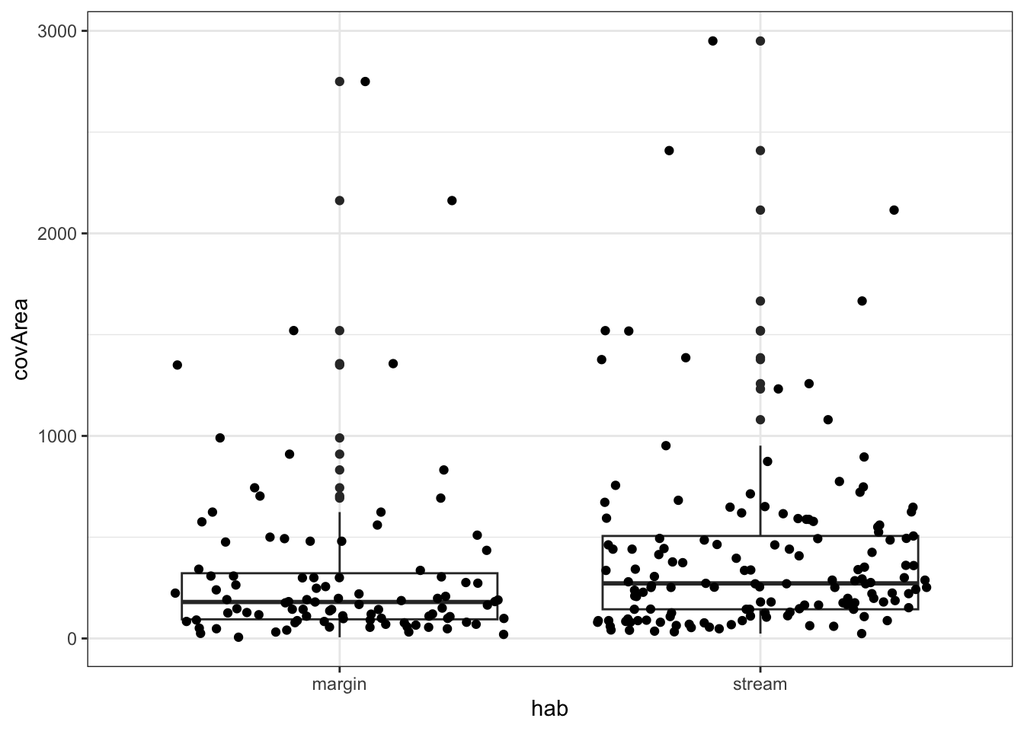

```r
pWS %>% ggplot(aes(x = hab, y = covArea)) + geom_boxplot() + geom_jitter() +
  theme_bw()
```

### FIGURE 6: LINEAR REGRESSION PLOT SHOWING SEAL SALAMANDER BODY SIZE VS COVER OBJECT AREA

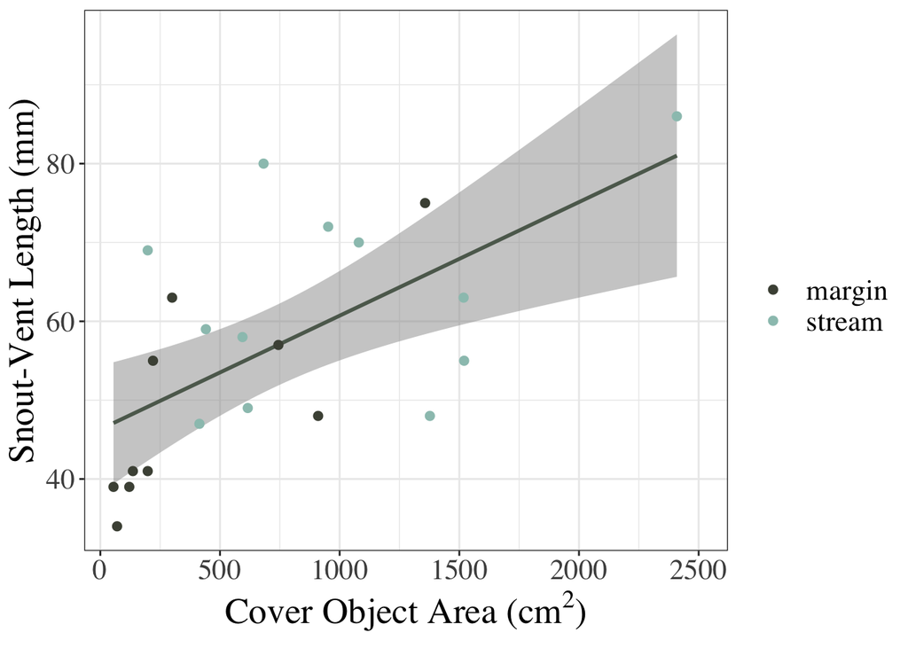

```r
lr = ggplot(pointsDCHE2, aes(x = covArea, y = mmSVL)) +
  geom_smooth( method = "lm", col= "#5D695C", alpha = 0.5) +
  geom_point(aes(col = hab),
             size = 2) +
  scale_color_manual(values = habCols) +
  labs(color = "") +
  xlab(expression(paste("Cover Object Area (", cm^{2}, ")"))) +
  ylab("Snout-Vent Length (mm)") +
  # labs(title = expression(
  #   paste(
  #     "Cover Object Area vs. ",
  #     italic("Desmognathus cheaha"),
  #     " mass"
  #     )
  #   ))+

  #facet_wrap(~hab) +
  theme_bw() +
  expand_limits(x = 2500) +
theme(strip.background = element_rect(fill = "transparent", color = "black"),
      text = element_text(size = 20, family = "Times"),
       panel.background = element_rect(fill='transparent'),
        plot.background = element_rect(fill='transparent', color=NA))


lr
```

# Community interactions

Our questions about community interactions center around the use of terrestrial vs aquatic microhaitat use

## do seals utilize more aquatic habitat than other species?

Looking at the sample size we have for this analysis

```r
pointsSealStream = points %>% filter(sealStream == 1) %>% filter(hab != "terrestrial") %>%
  mutate(Species = ifelse(Species == "CHOW", "CAM", Species)) %>% filter(Species %in% c("CAM", "DCHE", "DPER", "ECIR")) %>%
  mutate(Species = ifelse(Species == "CAM", "xCAM", Species)) %>%
  #filtering so that we're only in the sterams where all four taxa are represented
  filter(StrmID %in% c("STRM01", "STRM02", "STRM04", "STRM06", "STRM07", "STRM10") & Species %in% c("DCHE", "ECIR", "DPER"))


pointsSealComparison = points %>% filter(hab != "terrestrial") %>%
  mutate(Species = ifelse(Species == "CHOW", "CAM", Species)) %>% filter(Species %in% c("DCHE", "DPER", "ECIR"))


pointsSealComparison %>% group_by(Species) %>% dplyr::summarize(n()) %>% DT::datatable()
```

|  | Species | n() |
| --- | --- | --- |
| 1 | DCHE | 34 |
| 2 | DPER | 73 |
| 3 | ECIR | 31 |

We are conducting this analysis using all salamander microhabitat points that aren’t terrestrial, and that means disregarding co-occupancy at the stream level with other species. However, in cases where multiple salamanders occupied the same cover item, we are randomly selecting one of the observations to retain.

```r
pointsSealComparison = pointsSealComparison %>% mutate(habBin = ifelse(hab == "stream", 1, 0),
                                               Species = as.factor(Species))

set.seed(999)
pointsComparisonThin = pointsSealComparison %>% group_by(PointCode) %>% sample_n(size = 1)

pointsComparisonThin %>% group_by(Species) %>% summarize(n())
```

```
## # A tibble: 3 × 2
##   Species `n()`
##   <fct>   <int>
## 1 DCHE       28
## 2 DPER       68
## 3 ECIR       28
```

```r
compHab2 = glmmTMB(habBin ~ Species + (1|StrmID), data = pointsComparisonThin, family = "binomial")

summary(compHab2)
```

```
##  Family: binomial  ( logit )
## Formula:          habBin ~ Species + (1 | StrmID)
## Data: pointsComparisonThin
##
##      AIC      BIC   logLik deviance df.resid
##    170.8    182.0    -81.4    162.8      120
##
## Random effects:
##
## Conditional model:
##  Groups Name        Variance Std.Dev.
##  StrmID (Intercept) 0.3364   0.58
## Number of obs: 124, groups:  StrmID, 11
##
## Conditional model:
##             Estimate Std. Error z value Pr(>|z|)
## (Intercept)  0.70209    0.49849   1.408    0.159
## SpeciesDPER -1.11389    0.53399  -2.086    0.037 *
## SpeciesECIR -0.07569    0.61533  -0.123    0.902
## ---
## Signif. codes:  0 '***' 0.001 '**' 0.01 '*' 0.05 '.' 0.1 ' ' 1
```

```r
tab_model(compHab2)
```

|  | habBin |  |  |
| --- | --- | --- | --- |
| Predictors | Odds Ratios | CI | p |
| (Intercept) | 2.02 | 0.76 – 5.36 | 0.159 |
| Species [DPER] | 0.33 | 0.12 – 0.93 | **0.037** |
| Species [ECIR] | 0.93 | 0.28 – 3.10 | 0.902 |
| Random Effects |  |  |  |
| σ<sup>2</sup> | 3.29 |  |  |
| τ<sub>00</sub> <sub>StrmID</sub> | 0.34 |  |  |
| ICC | 0.09 |  |  |
| N <sub>StrmID</sub> | 11 |  |  |
| Observations | 124 |  |  |
| Marginal R<sup>2</sup> / Conditional R<sup>2</sup> | 0.074 / 0.160 |  |  |

```r
nullComp2 = glmmTMB(habBin ~ (1|StrmID), data = pointsComparisonThin, family = "binomial")

anova(nullComp2, compHab2, test = "Chisq")
```

```
## Data: pointsComparisonThin
## Models:
## nullComp2: habBin ~ (1 | StrmID), zi=~0, disp=~1
## compHab2: habBin ~ Species + (1 | StrmID), zi=~0, disp=~1
##           Df    AIC    BIC  logLik deviance  Chisq Chi Df Pr(>Chisq)
## nullComp2  2 174.01 179.66 -85.007   170.01
## compHab2   4 170.76 182.04 -81.381   162.76 7.2519      2    0.02662 *
## ---
## Signif. codes:  0 '***' 0.001 '**' 0.01 '*' 0.05 '.' 0.1 ' ' 1
```

### FIGURE 7

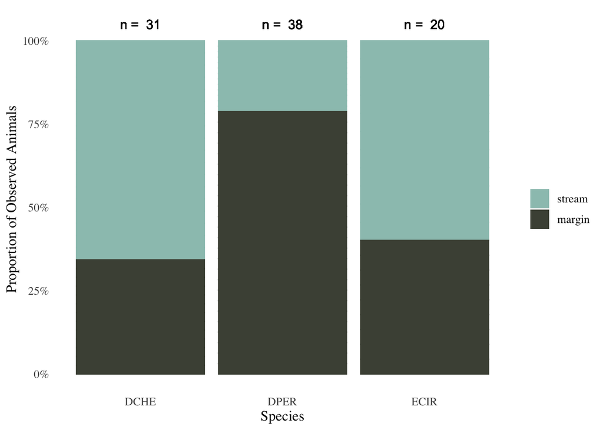

```r
dist = pointsSealStream %>%
  group_by(Species) %>%
  dplyr::mutate(spCount = n()) %>%
  ungroup() %>%
  group_by(Species, hab) %>%
  dplyr::mutate(habProp = n() / spCount) %>%
  ungroup()


FIG12 = dist %>% filter(Species %in% c("CAM", "DCHE", "DPER", "ECIR")) %>%
  ggplot(aes(x = Species, y = habProp, fill = factor(hab, levels = c("stream", "margin", "terrestrial")))) +
  geom_bar(stat = "identity", position = "fill",
           aes(col = factor(hab, levels = c("stream", "margin", "terrestrial"))
               )) +
  scale_fill_manual(values = habCols) +
    scale_color_manual(values = habCols) +
  guides(color="none") +
  scale_y_continuous(labels = scales::percent) +
  geom_text(aes(y = 1.05, label = paste("n = ", spCount))) +
  labs(fill = "") +
  theme_minimal() +
  ylab("Proportion of Observed Animals") +
  #title("Proportions of Commonly Observed Species Observed in Different Habitat Types") +
  theme(panel.grid.major = element_blank(),
    panel.grid.minor = element_blank()) + theme( text = element_text(size = 12, family = "Times"))

FIG12
```

## Do seals and duskies partition habitat?

Do duskies use more aquatic habitat in streams where we did not detect D cheaha?

### are there differing counts of rocks across streams?

```r
rockMod = lm(rockCount ~ StrmID, data = bandRocks)


summary(rockMod)
```

```
##
## Call:
## lm(formula = rockCount ~ StrmID, data = bandRocks)
##
## Residuals:
##    Min     1Q Median     3Q    Max
## -17.60  -4.80   0.60   4.85  21.40
##
## Coefficients:
##              Estimate Std. Error t value Pr(>|t|)
## (Intercept)    15.800      2.533   6.239  1.1e-08 ***
## StrmIDSTRM02   -2.800      3.582  -0.782 0.436214
## StrmIDSTRM03   11.900      3.582   3.323 0.001251 **
## StrmIDSTRM04   -4.500      3.582  -1.256 0.211920
## StrmIDSTRM05   -9.000      3.582  -2.513 0.013591 *
## StrmIDSTRM06    6.400      3.582   1.787 0.077013 .
## StrmIDSTRM07    5.300      3.582   1.480 0.142106
## StrmIDSTRM08   14.300      3.582   3.993 0.000126 ***
## StrmIDSTRM09    0.700      3.582   0.195 0.845447
## StrmIDSTRM10    4.500      3.582   1.256 0.211920
## StrmIDSTRM11    6.800      3.582   1.899 0.060530 .
## ---
## Signif. codes:  0 '***' 0.001 '**' 0.01 '*' 0.05 '.' 0.1 ' ' 1
##
## Residual standard error: 8.009 on 99 degrees of freedom
## Multiple R-squared:  0.4349, Adjusted R-squared:  0.3778
## F-statistic: 7.618 on 10 and 99 DF,  p-value: 6.524e-09
```

```r
x = Anova(rockMod)

summary(x)
```

```
##      Sum Sq           Df           F value          Pr(>F)
##  Min.   :4886   Min.   :10.00   Min.   :7.618   Min.   :0
##  1st Qu.:5252   1st Qu.:32.25   1st Qu.:7.618   1st Qu.:0
##  Median :5618   Median :54.50   Median :7.618   Median :0
##  Mean   :5618   Mean   :54.50   Mean   :7.618   Mean   :0
##  3rd Qu.:5984   3rd Qu.:76.75   3rd Qu.:7.618   3rd Qu.:0
##  Max.   :6350   Max.   :99.00   Max.   :7.618   Max.   :0
##                                 NA's   :1       NA's   :1
```

```r
dper = points %>% filter(Species == "DPER")


bandRocks = bandRocks %>% mutate(SubplotHab = paste(SubplotCode, HabitatType)) %>% select(SubplotHab, rockCount)

dper = dper %>% separate(SubplotCode, into = c("Stream2", "plot", "band"), sep = "-")

dper = dper %>% mutate(SubplotHab = paste0(StrmID, "-", band, " ", toupper(hab)))

dper = dper %>% filter(hab %in% c("margin", "stream")) %>% left_join(bandRocks, by = "SubplotHab", relationship = "many-to-many")

dper = dper %>% filter(duplicated(PointCode) == FALSE)
```

```r
dper2 = dper %>% filter(hab %in% c("stream", "margin") & CoverType %in% c("R", "W")) %>%
  mutate(hab2 = ifelse(hab == "stream", 1, 0))
```

Testing whether habitat utilization is dependent on the presence of D. cheaha in the stream

```r
dperNull = glmmTMB(hab2 ~ (1|StrmID), data = dper2, family = "binomial")

dperMod = glmmTMB(hab2 ~ sealStream + rockCount + (1|StrmID), data = dper2, family = "binomial")

dperSimpl = glmmTMB(hab2 ~ sealStream + (1|StrmID), data = dper2, family = "binomial")

AICc(dperMod)
```

```
## [1] 88.75139
```

```r
AICc(dperSimpl)
```

```
## [1] 86.46875
```

```r
anova(dperMod, dperNull, test = "Chisq")
```

```
## Data: dper2
## Models:
## dperNull: hab2 ~ (1 | StrmID), zi=~0, disp=~1
## dperMod: hab2 ~ sealStream + rockCount + (1 | StrmID), zi=~0, disp=~1
##          Df    AIC    BIC  logLik deviance  Chisq Chi Df Pr(>Chisq)
## dperNull  2 89.023 93.310 -42.512   85.023
## dperMod   4 88.062 96.634 -40.031   80.062 4.9615      2    0.08368 .
## ---
## Signif. codes:  0 '***' 0.001 '**' 0.01 '*' 0.05 '.' 0.1 ' ' 1
```

```r
anova(dperMod, dperSimpl, test = "Chisq")
```

```
## Data: dper2
## Models:
## dperSimpl: hab2 ~ sealStream + (1 | StrmID), zi=~0, disp=~1
## dperMod: hab2 ~ sealStream + rockCount + (1 | StrmID), zi=~0, disp=~1
##           Df    AIC    BIC  logLik deviance Chisq Chi Df Pr(>Chisq)
## dperSimpl  3 86.062 92.491 -40.031   80.062
## dperMod    4 88.062 96.634 -40.031   80.062 2e-04      1     0.9876
```

```r
  summary(dperMod)
```

```
##  Family: binomial  ( logit )
## Formula:          hab2 ~ sealStream + rockCount + (1 | StrmID)
## Data: dper2
##
##      AIC      BIC   logLik deviance df.resid
##     88.1     96.6    -40.0     80.1       59
##
## Random effects:
##
## Conditional model:
##  Groups Name        Variance  Std.Dev.
##  StrmID (Intercept) 4.493e-09 6.703e-05
## Number of obs: 63, groups:  StrmID, 10
##
## Conditional model:
##               Estimate Std. Error z value Pr(>|z|)
## (Intercept)  0.5457640  0.9971663   0.547   0.5842
## sealStream  -1.3216773  0.6488751  -2.037   0.0417 *
## rockCount    0.0004816  0.0310641   0.016   0.9876
## ---
## Signif. codes:  0 '***' 0.001 '**' 0.01 '*' 0.05 '.' 0.1 ' ' 1
```

```r
summary(dperSimpl)
```

```
##  Family: binomial  ( logit )
## Formula:          hab2 ~ sealStream + (1 | StrmID)
## Data: dper2
##
##      AIC      BIC   logLik deviance df.resid
##     86.1     92.5    -40.0     80.1       60
##
## Random effects:
##
## Conditional model:
##  Groups Name        Variance  Std.Dev.
##  StrmID (Intercept) 5.048e-09 7.105e-05
## Number of obs: 63, groups:  StrmID, 10
##
## Conditional model:
##             Estimate Std. Error z value Pr(>|z|)
## (Intercept)   0.5596     0.4432   1.263    0.207
## sealStream   -1.3269     0.5559  -2.387    0.017 *
## ---
## Signif. codes:  0 '***' 0.001 '**' 0.01 '*' 0.05 '.' 0.1 ' ' 1
```

```r
tab_model(dperMod)
```

|  | hab2 |  |  |
| --- | --- | --- | --- |
| Predictors | Odds Ratios | CI | p |
| (Intercept) | 1.73 | 0.24 – 12.18 | 0.584 |
| sealStream | 0.27 | 0.07 – 0.95 | **0.042** |
| rockCount | 1.00 | 0.94 – 1.06 | 0.988 |
| Random Effects |  |  |  |
| σ<sup>2</sup> | 3.29 |  |  |
| τ<sub>00</sub> <sub>StrmID</sub> | 0.00 |  |  |
| N <sub>StrmID</sub> | 10 |  |  |
| Observations | 63 |  |  |
| Marginal R<sup>2</sup> / Conditional R<sup>2</sup> | 0.110 / NA |  |  |

```r
# r.squaredGLMM(dperMod)
#
 r2_nakagawa(dperMod, tolerance = 0)
```

```
## # R2 for Mixed Models
##
##   Conditional R2: 0.110
##      Marginal R2: 0.110
```

```r
exp(-0.2153)
```

```
## [1] 0.8062995
```

```r
confint(dperMod)
```

```
##                                  2.5 %      97.5 %      Estimate
## (Intercept)                -1.40864601  2.50017394  5.457640e-01
## sealStream                 -2.59344917 -0.04990552 -1.321677e+00
## rockCount                  -0.06040287  0.06136598  4.815583e-04
## Std.Dev.(Intercept)|StrmID  0.00000000         Inf  6.703074e-05
```

### FIGURE 8: STACKED BARPLOT SHOWING DISTRIBUTION OF D PERLAPSUS

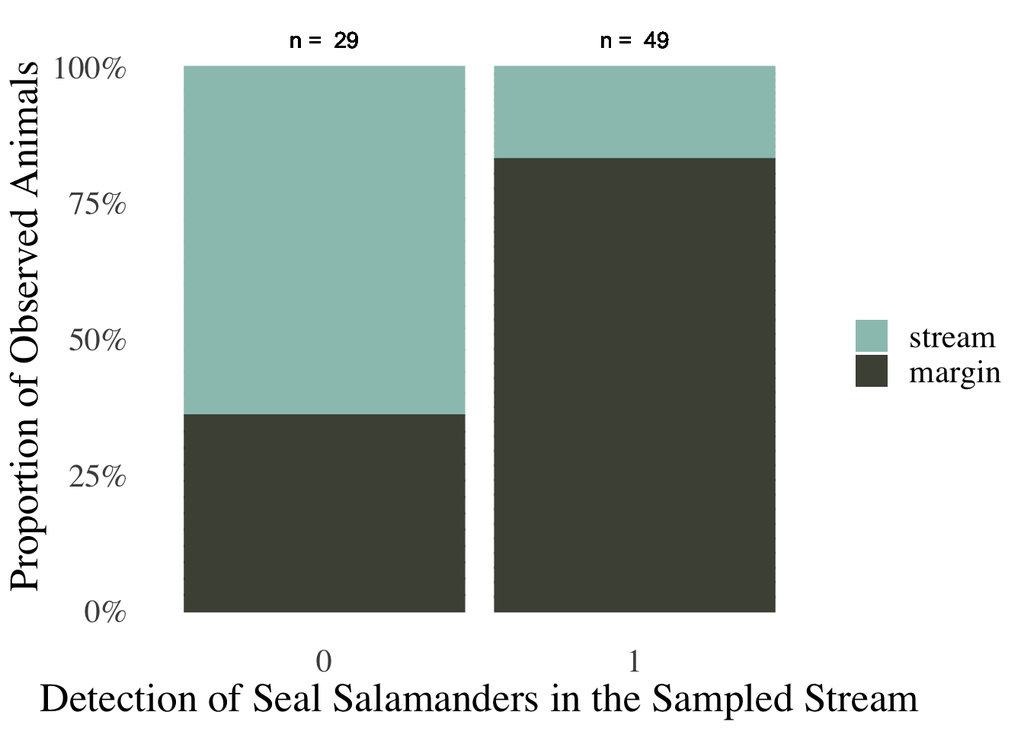

```r
dper = points %>% filter(Species %in% c("DPER")) %>%
  group_by(sealStream, Species) %>%
  dplyr::mutate(sSCount = dplyr::n()) %>%
  ungroup() %>%
  group_by(sealStream, hab, Species) %>%
  dplyr::mutate(habProp = dplyr::n() / sSCount) %>%
  ungroup()



dper2 = dper %>% filter(hab %in% c("stream", "margin"))

fig11 = dper2 %>%
  ggplot(aes(x = as.factor(sealStream), y = habProp, fill = factor(hab, levels = c("stream", "margin", "terrestrial")))) +
  geom_bar(stat = "identity", position = "fill",
           aes(col = factor(hab, levels = c("stream", "margin", "terrestrial"))
               )) +
  scale_fill_manual(values = habCols) +
    scale_color_manual(values = habCols) +
  guides(color="none") +
  scale_y_continuous(labels = scales::percent) +
  geom_text(aes(y = 1.05, label = paste("n = ", sSCount))) +
  labs(fill = ""#,
      # title = expression(paste("Cover Item Positions of ", italic("Desmognathus perlapsus")))
       ) +
  theme_minimal() +
  ylab("Proportion of Observed Animals") +
  xlab("Detection of Seal Salamanders in the Sampled Stream") +
  theme(panel.grid.major = element_blank(),
    panel.grid.minor = element_blank(),
    text = element_text(size = 20, family = "Times")
  )

fig11
```